This document explains plotting geospatial data using `ggplot2` and `{ggfortify}`.

# Plotting with `{maps}` package

`{ggplot2}` can load map data provided by `{maps}` and `{mapdata}` package via `map_data` function. Loaded data is automatically converted to `data.frame`, thus you can plot maps via `ggplot` as below.

```r
library(mapdata)
library(ggplot2)

jp <- ggplot2::map_data('world2', 'japan')
class(jp)
```

```
## [1] "data.frame"
```

```r
head(jp)
```

```
##       long      lat group order region     subregion
## 1 123.8887 24.28013     1     1  Japan Iriomote Jima
## 2 123.8256 24.26606     1     2  Japan Iriomote Jima
## 3 123.7498 24.28330     1     3  Japan Iriomote Jima
## 4 123.6807 24.28804     1     4  Japan Iriomote Jima
## 5 123.6798 24.31777     1     5  Japan Iriomote Jima
## 6 123.7523 24.34849     1     6  Japan Iriomote Jima
```

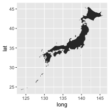

```r
ggplot(jp, aes(x = long, y = lat, group = group)) +
  geom_polygon()
```

`{ggfortify}` additionally allows to `autoplot` `map` instances as it is. You can specify `geom` and other options to controll the outlooks.

```r
library(ggfortify)
jp <-  map('world2', 'japan', plot = FALSE, fill = TRUE)
class(jp)
```

```
## [1] "map"
```

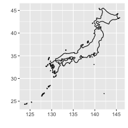

```r
autoplot(jp)
```

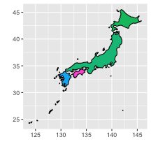

```r
p <- autoplot(jp, geom = 'polygon', fill = 'subregion') +
  theme(legend.position="none")
p
```

Also, `maps` package provides some geospatial data. Following example retrieves Japanese city locations from world's city locations. Then plot on the previous map.

```r
cities <- get('world.cities')
cities <- cities[cities$country.etc == 'Japan', ]
head(cities)
```

```
##         name country.etc    pop   lat   long capital
## 189 Abashiri       Japan  42324 44.02 144.27       0
## 221    Abiko       Japan 132577 35.88 140.03       0
## 481     Ageo       Japan 220766 35.95 139.61       0
## 514      Ago       Japan  23876 34.33 136.82       0
## 571     Agui       Japan  24227 34.95 136.91       0
## 629   Aikawa       Japan  43599 35.55 139.29       0
```

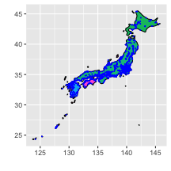

```r
p + geom_point(data = cities, aes(x = long, y = lat),
               colour = 'blue', size = 0.1)
```

Because map plot created by `{ggfortify}` has a setting of `aes(x = long, y = lat)`, you don't have to specify `x` and `y` aethetics in this case.

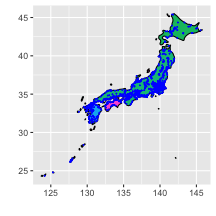

```r
p + geom_point(data = cities, colour = 'blue', size = 0.1)
```

# Plotting with `{sp}` package

Also, `{ggfortify}` can supports geospatial instances defined in `{sp}` package. Actually some functions are defined in `{ggplot2}`. Following table shows where each function is defined.

| class | `fortify` | `autoplot` |
| --- | --- | --- |
| `Line` | `{ggplot2}` | `{ggfortify}` |
| `Lines` | `{ggplot2}` | `{ggfortify}` |
| `Polygon` | `{ggplot2}` | `{ggfortify}` |
| `Polygons` | `{ggplot2}` | `{ggfortify}` |
| `SpatialLines` | `{ggfortify}` | `{ggfortify}` |
| `SpatialLinesDataFrame` | `{ggplot2}` | `{ggfortify}` |
| `SpatialPoints` | `{ggfortify}` | `{ggfortify}` |
| `SpatialPointsDataFrame` | `{ggfortify}` | `{ggfortify}` |
| `SpatialPolygons` | `{ggplot2}` | `{ggfortify}` |
| `SpatialPolygonsDataFrame` | `{ggplot2}` | `{ggfortify}` |

Following example creates `SpatialPointsDataFrame` of some Japanese city's populatios, then plot it via `autoplot`. Note that you `geom` is specified by the original `{sp}` class. `SpatialPoints` is plot using `geom_point` for example.

```r
library(sp)
df <- data.frame(long = c(139.691704, 135.519711),
                 lat = c(35.689521, 34.686316),
                 label = c('Tokyo', 'Osaka'),
                 population = c(1335, 886))
coordinates(df) <- ~ long + lat
class(df)
```

```
## [1] "SpatialPointsDataFrame"
## attr(,"package")
## [1] "sp"
```

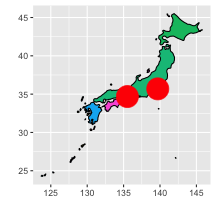

```r
autoplot(df, p = p, colour = 'red', size = 10)
```

Also, you can use other columns as aethetics.

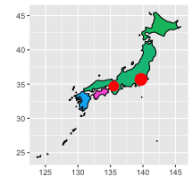

```r
autoplot(df, p = p, colour = 'red', size = 'population') +
  scale_size_area()
```

# Plotting with other packages

`autoplot` has `p` keyword to take existing `ggplot` instance. Below example plots `SpatialPointsDataFrame` on the `ggmap`.

[figure not shown]

```r
library(ggmap)
bbox <- c(130.0, 30.0, 145.0, 45.0)
map <- get_openstreetmap(bbox = bbox, scale = 47500000)
p <- ggmap(map)
autoplot(df, p = p, colour = 'red', size = 'population') +
  scale_size_area() +
  theme(legend.justification = c(1, 0), legend.position = c(1, 0))
```